# Introduction to Hierarchical Clustering

This lab continues our study of *clustering*, or methods for identifying meaningful groupings of similar data-points.

**Directions** (Please read before starting)

1. Please *work together* with your assigned partner. Make sure you both fully understand each concept before you move on.
2. Please record your answers and any related code for all embedded lab questions. I encourage you to try out the embedded examples, but you shouldn’t turn them in.
3. Please ask for help, clarification, or even just a check-in if anything seems unclear.

$~$

## Preamble

### Packages and Datasets

This lab will continue using the `factoextra` package, and will also use some functions from the `cluster` package.

```r
# load the following packages
# install.packages("cluster")
library(cluster)
library(factoextra)
library(ggplot2)
library(dplyr)
```

$~$

### Distance and Categorical Variables

Clustering aims to group data-points according to similarity. Ideally, clusters should be *cohesive* (all members are close to each other) while achieving *separation* (cluster members are far from the members of other clusters).

We first measured “closeness” using **euclidean distance**:
$$d_{eu}(a,b) =
\sqrt{\sum_{j = 1}^{p} (x_{aj} - x_{bj})^2}$$

Notice that euclidean distance is undefined when variable $X_J$ is *categorical*. An alternative measure is **Gower distance**:
$$d_{G}(a,b) = \tfrac{1}{p}\sum_{j = 1}^{p} h_j(
x_{a,j}, x_{b,j})$$

Here the function $h_j()$ depends on the variable type of $X_j$ - For numeric variables, $h_j(x_{a,j}, x_{b,j}) = \tfrac{|x_{a,j} - x_{b,j}|}{R_j}$, where $R_j$ is the range of the $j^{th}$ variable - For categorical variables, $h_j(x_{a,j}, x_{b,j}) = 0$ if the $x_{a,j}$ and $x_{b,j}$ are the same category, and $h_j(x_{a,j}, x_{b,j}) = 1$ otherwise

Notice that $h_j()$ has a range of $[0,1]$ regardless of whether $X_j$ is categorical or numeric, so Gower distance will implicitly standardizing the data in a way that euclidean distance does not.

$~$

### Distance Matrices

We can see Gower Distance in action using a **distance matrix**, or an $n$ by $n$ matrix displaying the distance between all possible pairings of data-points.

Consider a data set of 6 yes/no questions describing $n = 20$ different animal species:

|  | Warm-blooded? | Can_fly? | Vertebrate? | Endangered? | Lives_in_groups? | Has_hair? |
| --- | --- | --- | --- | --- | --- | --- |
| ant | No | No | No | No | Yes | No |
| bee | No | Yes | No | No | Yes | Yes |
| cat | Yes | No | Yes | No | No | Yes |
| cpl | No | No | No | No | No | Yes |
| chi | Yes | No | Yes | Yes | Yes | Yes |
| cow | Yes | No | Yes | No | Yes | Yes |
| duc | Yes | Yes | Yes | No | Yes | No |
| eag | Yes | Yes | Yes | Yes | No | No |
| ele | Yes | No | Yes | Yes | Yes | No |
| fly | No | Yes | No | No | No | No |
| fro | No | No | Yes | Yes | NA | No |
| her | No | No | Yes | No | Yes | No |
| lio | Yes | No | Yes | NA | Yes | Yes |
| liz | No | No | Yes | No | No | No |
| lob | No | No | No | No | NA | No |
| man | Yes | No | Yes | Yes | Yes | Yes |
| rab | Yes | No | Yes | No | Yes | Yes |
| sal | No | No | Yes | No | NA | No |
| spi | No | No | No | NA | No | Yes |
| wha | Yes | No | Yes | Yes | Yes | No |

$~$

We can calculate a matrix of Gower distances using the `daisy()` function in the `cluster` package:

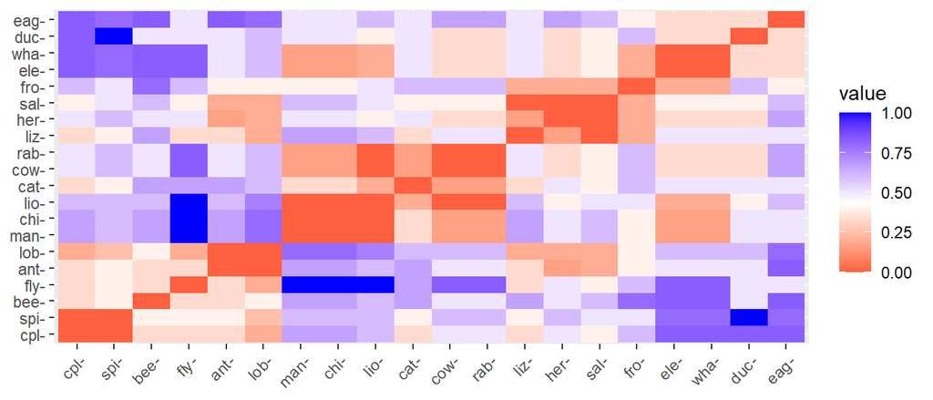

```r
animals <- read.csv("https://remiller1450.github.io/data/animals.csv", row.names = 1, stringsAsFactors = TRUE)
D <- daisy(animals, metric = "gower")  ## Calculate distance matrix
fviz_dist(D)  ## Visualize
```

We can then visualize the distance matrix using `fviz_dist()`.

- Why are all entries on the diagonal of this matrix exactly 0?
- What must be true of lions (“lio”) and flys (“fly”) for their distance to be 1?

$~$

### Hierarchical Clustering

Unlike $k$-means and PAM, which rely on cluster centers, **hierarchical clustering** can be applied to *any distance matrix* without constraints on the individual data-points.

Hierarchical clustering organizes the data into a nested, tree-like structure known as a **dendrogram**:

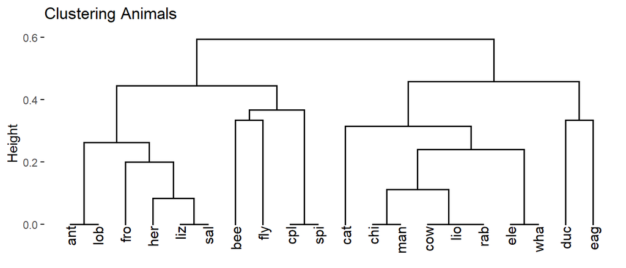

```r
ag <- agnes(D)  ## Apply a hierarchical clustering algorithm
fviz_dend(ag) + labs(title = "Clustering Animals")  ## Display the dendrogram
```

- The top of the dendrogram is a single cluster containing all observations (ie: $k = 1$)
- The bottom of the dendrogram has every observation in its own cluster (ie: $k = n$)
- The y-value at which two clusters merge is the average distance between those clusters

To obtain partitional clusters, we can “cut” a dendrogram:

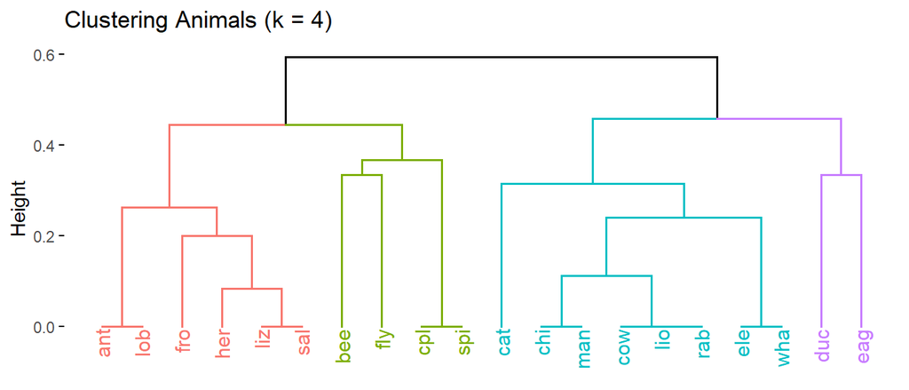

```r
fviz_dend(ag, k = 4) + labs(title = "Clustering Animals (k = 4)")
```

$~$

## Lab

### Hierarchical Clustering Algorithms

There are two broad approaches to hierarchical clustering:

- **Agglomerative**, or “bottom-up” approaches, that start with each data-point as its own cluster (leaf) and combine similar clusters (branches) until all of the data-points are grouped together in single cluster (root).
- **Divisive**, or “top-down” approaches, that start all of the data-points in a single cluster (root), then divides that cluster into smaller clusters (branches). These divisions continue until each data-point is its own cluster (leaf).

The acronyms AGNES (AGglomerative NESting) and DIANA (DIvisive ANAlysis) describe two of the most popular methods, and the code below demonstrates each:

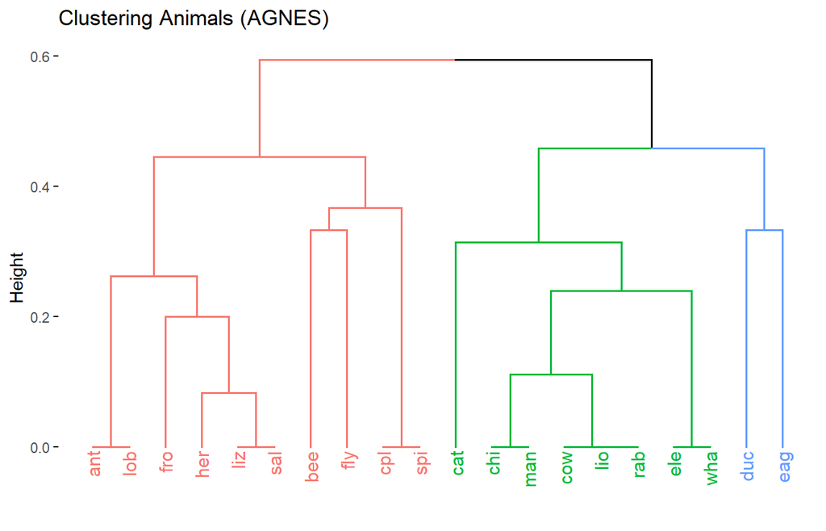

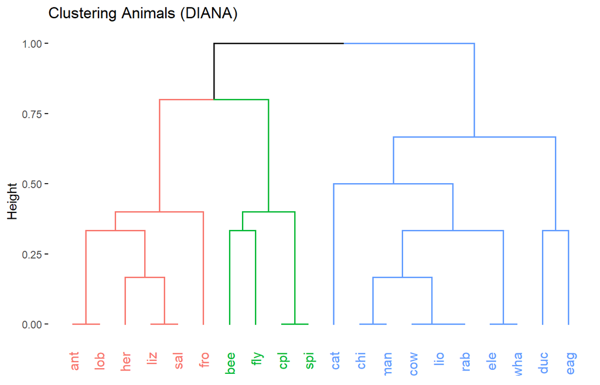

```r
D <- daisy(animals, metric = "gower")

ag <- agnes(D)
fviz_dend(ag, k = 3) + labs(title = "Clustering Animals (AGNES)")

di <- diana(D)
fviz_dend(di, k = 3) + labs(title = "Clustering Animals (DIANA)")
```

AGNES and DIANA are *greedy algorithms* (where each step is locally optimized), so they generally will not produce the same dendrogram.

At each step, AGNES looks to merge the two most similar clusters using one of the following methods:

- `method = "average"` - the average distance between all data-points in one cluster relative to those in another cluster
- `method = "single"` - the smallest distance between a single data-point in one cluster relative to another cluster (nearest neighbor)
- `method = "complete` - the smallest instance of the largest distance between a single data-point in one cluster relative to another cluster (furthest neighbor)

At each step, DIANA finds the cluster with the *largest diameter* (largest average distance among its own members) and looks for the *most disparate observation*, defined by the largest average distance from the other members. This observation is split off to form a “splinter group”, and average distances are used to iteratively assign the members of the original cluster to either join the “splinter group” or stay in the “original party”.

**Question #1**: The code below applies the AGNES algorithm with `method = "single"` to the `USArrests` data using the matrix of euclidean distances calculated after the data are standardized. For Question #1, use the provided code and its output to answer the following questions:

**Part A**: How many clusters were present at the initialization (start) of this clustering algorithm?

**Part B**: What was the first merge/split that occurred? Use the distance matrix, `D`, to briefly justify why this merge/split happened first. *Hint*: `min(D)` will return the distance between the closest two data-points. You can confirm that this distance corresponds to the merge/split you identified by using `View(as.matrix(D))`.

**Part C**: If this dendrogram were cut to obtain $k = 3$ clusters, how many members would belong to the largest of these clusters? *Note*: You may answer this question without writing any of your own code.

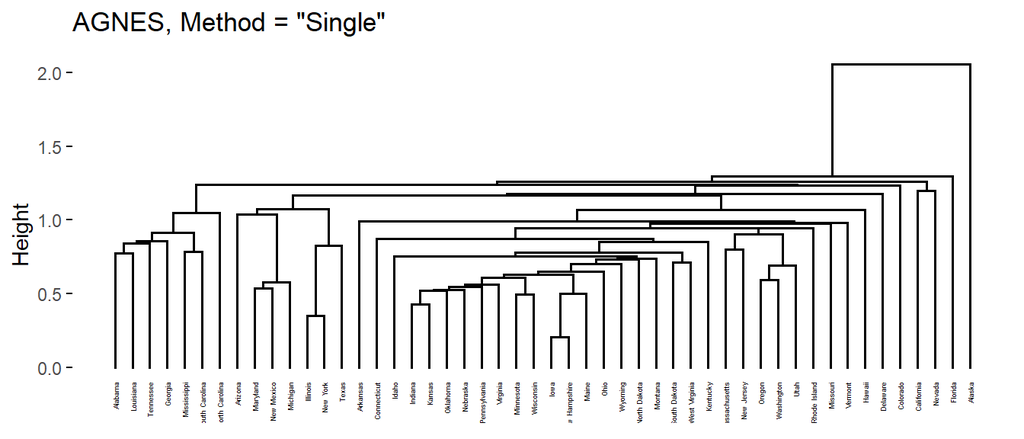

```r
data("USArrests")
USArrests_std <- scale(USArrests)
D <- daisy(USArrests_std, metric = "euclidean")

ag1 <- agnes(D, method = "single")
fviz_dend(ag1, cex = 0.25) + labs(title = 'AGNES, Method = "Single"')
```

**Question #2**: The code below applies the DIANA algorithm to the distance matrix calculated from the standardized `USarrests` data. Using the code and output provided below, answer the following questions:

**Part A**: How many clusters were present at the initialization (start) of this algorithm?

**Part B**: Briefly describe the merge/split resulting from the first step of the algorithm.

**Part C**: Which observation you believe was used to form the “splinter group” in the first step of the algorithm? Justify your answer. *Hint*: Try using the `apply()` function to find mean distances between each observation. To do this, you’ll need to coerce `D` into a matrix using `as.matrix()`.

**Part D**: Using the y-axis of the dendrogram, what is the approximate average euclidean distance between the members of the clusters created by the first merge/split?

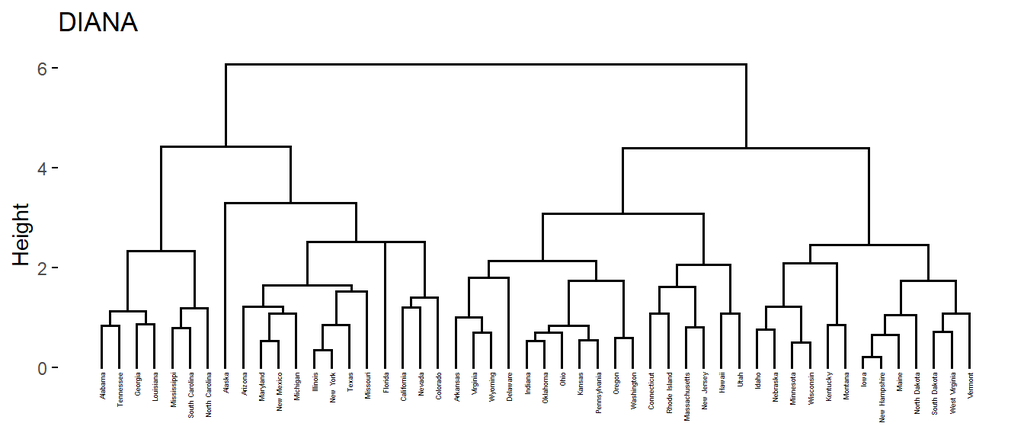

```r
di1 <- diana(D)
fviz_dend(di1, cex = 0.25) + labs(title = 'DIANA')
```

$~$

### Where to cut?

Dendrograms provide a unique perspective on the relationships between data-points, but oftentimes we’d still like to report cluster membership for an optimized choice of $k$.

Fortunately, all of the methods described in our previous clustering lab can be applied to hierarchical methods (with the important caveat that all variables are numeric!) The code below demonstrates these three methods using DIANA clustering on the data described in Question #2.

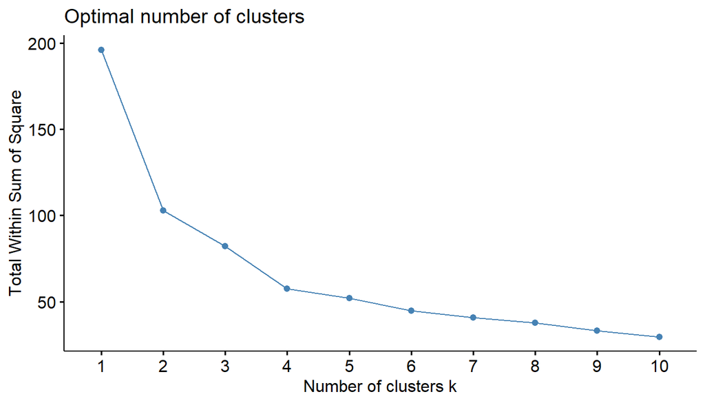

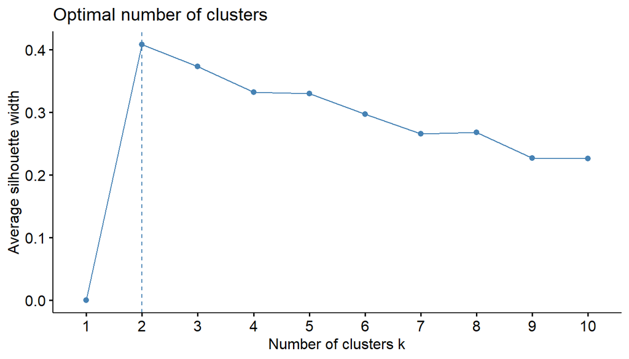

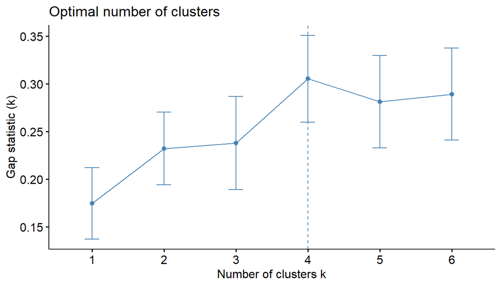

```r
### The elbow method
fviz_nbclust(USArrests_std, FUNcluster = hcut, hc_func = "diana", method = "wss")

### The average silhouette method
fviz_nbclust(USArrests_std, FUNcluster = hcut, hc_func = "diana", method = "silhouette")

## The gap statistic method
fviz_nbclust(USArrests_std, FUNcluster = hcut, hc_func = "diana", method = "gap",
             k.max = 6, verbose = FALSE)
```

The argument `FUNcluster = hcut` indicates the use of hierarchical clustering that is to be cut into clusters, while the argument `hc_func` specifies the hierarchical clustering algorithm to be used.

**Question #3**: The code below creates `cds`, a standardized subset of the Colleges 2019 data set that was described in our previous clustering lab. For this question, use the average silhouette method to find the optimal value of $k$ for AGNES clustering performed on these data. Then, graph a dendrogram displaying the AGNES results with branches colored according to this value of $k$. You should use euclidean distance in your analysis.

```r
colleges <- read.csv("https://remiller1450.github.io/data/Colleges2019.csv")
cd <- colleges %>% filter(State == "IA") %>%
  select(Name, Enrollment, Adm_Rate, ACT_median,
         Net_Tuition, FourYearComp_Males, FourYearComp_Females,
        Debt_median, Salary10yr_median)
cd <- cd[complete.cases(cd),]  ## Keeps only complete cases (no missing values)
rownames(cd) <- cd$Name
cds <- scale(select(cd, -Name))
```

$~$

### Practice

**Question #4**: The “European foods” data set summarizes the results of a household survey administered to 16 European nations in 1975. The survey asked households whether they had various foods in their house at the time of the questionnaire. The data below display the percentage of households in each country that had the food in question.

```r
euro <- read.csv("https://remiller1450.github.io/data/europeanfoods.csv", row.names = 1, stringsAsFactors = TRUE)
```

**Part A**: Create a distance matrix using euclidean distance *without standardizing* (since all variables are already on the same 0-100 scale). Then, visualize this matrix using `fviz_dist()`. Which country’s household food habits are *most similar* to Britain’s?

**Part B**: Use AGNES clustering with average distance as the merging method to create a dendrogram displaying these data.

**Part C**: Use DIANA clustering to create a dendrogram displaying these data.

**Part D**: Sweden, Norway, Denmark, and Finland are commonly grouped together in a region referred to as the [Nordic Countries](https://en.wikipedia.org/wiki/Nordic_countries). Which algorithm, AGNES or DIANA, seems to do a better job capturing this grouping? Briefly explain your answer.

**Part E**: Use the average silhouette method to determine an optimal number of clusters for the application of AGNES clustering in Part B. Then, use this value to color the dendrogram you created in Part B.

**Part F**: Use the gap statistic to determine an optimal number of clusters. Does this method agree with the average silhouette approach?

$~$

**Question #5**: The “starwars” data set documents the attributes of major characters in the Star Wars film series. For this question, you will perform a cluster analysis on the subset created below:

```r
data("starwars")
sw <- starwars %>%
  select(name, height, mass, hair_color, skin_color, eye_color, birth_year, sex, gender, homeworld, species) %>%
  mutate_if(is.character, as.factor)
sw <- as.data.frame(sw[complete.cases(sw),])
rownames(sw) <- sw$name
sw <- select(sw, -name)
```

**Part A**: After inspecting the data, `sw`, briefly explain why Gower distance is the most appropriate metric for measuring distances between characters.

**Part B**: Create a distance matrix and visualize it using `fviz_dist()`.

**Part C**: Using the AGNES algorithm, create a dendrogram displaying these data.

**Part D (optional, not graded)**: If you are familiar with Star Wars, do any relationships displayed in the dendrogram from Part C stand out as particularly interesting?